# Dominance Through the Lens of a Competitive Worldview

Study 4: Analysis Report

# Background

While Studies 1-3B provide correlational evidence that relationship expectancies shape dominant behavior and that worldviews, in turn, shape relationship expectancies, several important causal questions remain. In particular, is it possible to shift relationship expectancies … and would doing so change behavioral dominance? Study 4 tackles these questions by experimentally manipulating the expected relationship impact of dominant behavior and measuring its effect on incentive-compatible dominant behavior. Specifically, we posit that experimentally channeling participants’ attention to the negative, as opposed to positive, relationship consequences of dominant behavior will lead them to behave less dominantly. Additionally, we explore whether this relationship expectancy will explain the causal effect over and above compliance expectancies about the specific task and pre-existing competitive worldviews. To that end, we adapt the paradigm from Study 3A, putting participants into the manager role, and introduce a manipulation of relationship expectancies.

# Procedure

Participants were given the same scenario, introduction, and context as the manager side of Study 3A. They were told to imagine that they were managers in a mid-sized company and that they needed to assign a task to an employee who would be randomly assigned to them. The incentive structure was identical to the one in Study 3A, with one exception: Instead of a $2 potential bonus, the potential bonus was $1 (for managers and employees). To motivate the employee, the manager could send one of two messages: A dominant message or a non-dominant message. After reading the scenario, incentive structure, and messages, participants were randomly assigned to one of two experimental conditions: The Positive Relationship Impact Condition or the Negative Relationship Impact Condition. Accordingly, they were asked to think and write about how the employee might react [positively/negatively] to the dominant message. Specifically, they wrote about [positive/negative] thoughts or feeling the employee could have about the manager and their relationship with them. Participants then selected which message to send and made predictions about the relationship and compliance impact of sending the dominant message. Next, they indicated the extent to which they preferred the message they selected over the other. Finally, they completed a measure of competitive worldview.

# Preregistered hypotheses

This study was preregistered here: [Open Science Framework](https://osf.io/86me4/?view_only=d6414b68148a4dd1b87bba265095a7bf)

1. Participants in the positive relationship impact condition, as opposed to those in the negative relationship impact condition, will be more likely to select the dominant, as opposed to non-dominant, message.
2. Participants in the positive relationship impact condition, as opposed to those in the negative relationship impact condition, will predict more positive relationship impact of sending the dominant message.
3. The relationship between condition and selecting the dominant message will be at least partially explained by the predicted relationship impact of sending the dominant message.

# Data collection

Participants were recruited through Connect by CloudResearch - an online participant pool.

Total N = **503**.

Responses were filtered for two quality checks: (1) a simple attention check; (2) a bot detection check.

| att_1 | att_2 | N |
| --- | --- | --- |
| 1 | 1 | 492 |
| 0 | 1 | 7 |
| 1 | 0 | 4 |

Eligible N = **492**.

## Race/Ethnicity

```r
df_s4 %>%
  group_by(race) %>%
  summarise(N = n()) %>%
  ungroup() %>%
  mutate(Perc = round(100*(N/sum(N)),2)) %>%
  ungroup() %>%
  arrange(desc(Perc)) %>%
  kbl() %>%
  kable_styling(bootstrap_options = "hover",
                full_width = F,
                position = "left")
```

| race | N | Perc |
| --- | --- | --- |
| white | 339 | 67.40 |
| black | 60 | 11.93 |
| asian | 49 | 9.74 |
| hispanic | 25 | 4.97 |
| multiracial | 21 | 4.17 |
| NA | 9 | 1.79 |

## Gender

```r
df_s4 %>%
  mutate(gender = ifelse(is.na(gender) | gender == "","other",gender)) %>%
  group_by(gender) %>%
  summarise(N = n()) %>%
  ungroup() %>%
  mutate(Perc = round(100*(N/sum(N)),2)) %>%
  ungroup() %>%
  arrange(desc(Perc)) %>%
  kbl() %>%
  kable_styling(bootstrap_options = "hover",
                full_width = F,
                position = "left")
```

| gender | N | Perc |
| --- | --- | --- |
| man | 257 | 51.09 |
| woman | 244 | 48.51 |
| other | 2 | 0.40 |

### Age

```r
df_s4 %>%
  summarise(age_mean = round(mean(age,na.rm = T),2),
            age_sd = round(sd(age,na.rm = T),2)) %>%
  kbl() %>%
  kable_styling(bootstrap_options = "hover",
                full_width = F,
                position = "left")
```

| age_mean | age_sd |
| --- | --- |
| 38.84 | 11.54 |

### Education

```r
df_s4 %>%
  group_by(edu) %>%
  summarise(N = n()) %>%
  ungroup() %>%
  mutate(Perc = round(100*(N/sum(N)),2)) %>%
  ungroup() %>%
  kbl() %>%
  kable_styling(bootstrap_options = "hover",
                full_width = F,
                position = "left")
```

| edu | N | Perc |
| --- | --- | --- |
| GED | 107 | 21.27 |
| 2yearColl | 63 | 12.52 |
| 4yearColl | 230 | 45.73 |
| MA | 75 | 14.91 |
| PHD | 26 | 5.17 |
| NA | 2 | 0.40 |

### Income

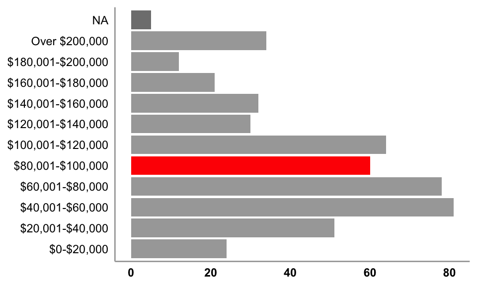

```r
median_income_num <- df_s4_elg %>%
  summarise(median = median(income_num,na.rm = T))

median_income <- median_income_num %>%
  mutate(income_char = case_when(median == 1 ~ "$0-$20,000",
                                 median == 2 ~ "$20,001-$40,000",
                                 median == 3 ~ "$40,001-$60,000",
                                 median == 4 ~ "$60,001-$80,000",
                                 median == 5 ~ "$80,001-$100,000",
                                 median == 6 ~ "$100,001-$120,000",
                                 median == 7 ~ "$120,001-$140,000",
                                 median == 8 ~ "$140,001-$160,000",
                                 median == 9 ~ "$160,001-$180,000",
                                 median == 10 ~ "$180,001-$200,000",
                                 median == 11 ~ "Over $200,000")) %>%
  select(income_char) %>%
  unlist() %>%
  unname()

df_s4_elg %>%
  ggplot(aes(x = income, fill = income == median_income)) +
  geom_bar(show.legend = FALSE) +
  scale_fill_manual(values = c("FALSE" = "grey66", "TRUE" = "red")) +
  theme(panel.grid.major = element_blank(),
        panel.grid.minor = element_blank(),
        panel.background = element_blank(),
        axis.ticks = element_blank(),
        axis.line = element_line(color = "grey66"),
        axis.text.y = element_text(color = "black"),
        axis.text.x = element_text(color = "black",
                                   face = "bold"),
        axis.title.x = element_blank(),
        axis.title.y = element_blank()) +
  coord_flip()
```

Median income: **$80,001-$100,000**.

# Experimental Manipulation

Depending on the condition participants were randomly assigned to, they were asked to reflect on and write about either the **positive** or **negative** relationship impact of sending the dominant message. The manipulation prompt read as follows (paste disabled; 50-character minimum):

Before you make your choice of which message you want to send, think for a moment about how your employee might react [positively/negatively] to this message:

*By now you know the task at hand. It’s time to get in there and do your absolute best across all rounds. If you don’t complete it and do it well, you will not get the full bonus.*

How and why might the employee have a **positive/negative** (or at least not **negative/positive**) reaction to that message, affecting their attitude towards the manager?

In the space below, please write 1-2 sentences about **positive/negative** thoughts or feelings they could have about the manager and their relationship with them.

## Positive Condition

```r
df_s4_elg %>%
  filter(cond == "pos") %>%
  select(reflection) %>%
  kbl() %>%
  kable_styling(bootstrap_options = "hover",
                position = "left") %>%
  scroll_box(width = "100%", height = "400px")
```

| reflection |
| --- |
| It starts out positive, which is good. It is strongly worded, so that the person knows that it is up to them to do the job well and to get the bonus. |
| I think this message is encouraging and also acknowledging that the employee is capable of doing the task and knowing what is ahead. |
| I believe in a positive management style, as that is what I respond to better and what I have witnessed most other people responding better to. |
| They might be motivated at the possibility of earning a bonus for their work. They also might find tougher words motivating. |
| No one wants someone to speak demeaningly to them. Honey attracts, vinegar offends. It’s motivating to be spoken to with positivity. |
| They might think the manager has confidence they can do the job well and that is why they were chosen for the task. |
| The employee might think that they respect their manager and appreciate the effort they do to running the department, so they will do their best to ensure work is done correctly. |
| The employee would feel motivated to achieve the bonus and feel like they have some ownership over their ability to earn more money. |
| The employee might positively see the upcoming bonus as incentive for doing a good and thorough job. They could consider teamwork and that if they look out for their boss, their boss will also look ou… |
| This message would impact the employee negatively because it’s a very aggressive message. It comes off as a threat as in “do well or you don’t get paid”. I think a better approach is to encourage them… |
| I would think that the positive aspect is telling them that they should do their best. That’s encouraging. |
| They feel positive about being encouraged to do their best and the possibility of a bonus. |
| The employee would have a positive reaction to knowing the manager has confidence in them, and that they have the potential to earn a bonus. |
| They think the manager is the best at makeing sure their job goes easy and efficient. |
| I think it seems to be slightly motivating. I think this may get the person to give it their all. |
| We start by affirming the employee knows the task at hand suggesting there is confidence in their ability to perform the task successfully. |
| the employee might feel negative because this message is almost degrading like knowing what to do and they might not know what to do with this description its mainly focused on getting the bonus |
| They will know they will be rewarded for their hard work. I think with this incentive they will do really well in the task. |
| The employee may see this as a welcome challenge. Hopefully they would be incentivized to work toward getting the full bonus and doing their best! |
| The employee might feel a bit more motivated knowing that there is a potential bonus involved. They might also feel that their manager sees value in them for assigning them this task in the first plac… |
| The message conveys a sense of trust in the employee - “time to get in there and do your absolute best” would make the employee feel as if the manager specifically selected them for this task based on… |
| While the message may seem curt, in truth, the manager is not being critical or mean. By presenting the scenario honestly, they are providing me with the knowledge I need to win, and expressing our sh… |
| The above message hints that you (the boss) are the one who can withhold a bonus for completing the task correctly |
| I think positively the employee would think it’s nice that the manager is so encouraging. |
| The message above will likely not give a positive reaction from the employee. The message is a bit demanding, and threatens rather than directs. |
| The message is encouraging, but also sets a firm standard, which most people would respond positively to |
| The tone of a message will describe the attitude used to complete a given task |
| There would want to earn the bonus and look at it as a challenge and want to compete |
| The positive thought is that if the employee do well, they’ll get a bonus. Having the possibility to receive a bonus can be motivation for doing well. |
| I feel they would be encouraged to do their hardest, and to not let the manager down. By doing their best and pushing forward to make sure they get that full bonus. |

[output cut: 217 more lines]

## Negative Condition

```r
df_s4_elg %>%
  filter(cond == "neg") %>%
  select(reflection) %>%
  kbl() %>%
  kable_styling(bootstrap_options = "hover",
                position = "left") %>%
  scroll_box(width = "100%", height = "400px")
```

| reflection |
| --- |
| The employee could feel negative pressure. The relationship between manager and employee could be fractured. If my boss sent this to me, I would begin looking for a new job. |
| I feel like the message is a tad harsh to be honest. It’s a little aggressive and just not that nice. |
| I think they would feel as if their manager isn’t encouraging them to earn the bonus. I think they would feel their manager doesn’t believe in their ability to get the bonus. |
| The message provided has a very condescending tone, it devalues the employee’s worth to just their bonus. |
| They might feel that they are being pressured and would not want to do their best |
| They might feel pressured and resentful, they could take the message as a threat rather than encouragement. This could make them feel demotivated and viewing the manager as overly demanding. They migh… |
| They could view this message as negative because it seems more like a demand. |
| The employee may see this as unfriendly and an ultimatum. Rather than focusing on success this seems more like a threat. |
| It’s using negative reinforcement - this is the punishment for not doing it well. |
| This message emphasizes what is at stake to be lost and can be felt like a threat. |
| They might have a negative opinion about their manager taking away a bonus from them and that they are being controlled and punished. |
| They might think that the manager is kind of rude and not very cordial. Although the manager is just telling the truth, it could have come across a bit friendlier. |
| negative thoughts focus on not getting the full bonus, and focus on not performing well. |
| The message appears single minded. It lacks compassion and motivation. The message appears like the manager wants the employee to perform well for the manager’s montary gains. This may decrease moral. |
| It is a little threatening by noting what will happen if they don’t do well. It also is a little vague in terms of what doing well is. |
| It might create negative feelings because it seems a bit curt and not very encouraging. |
| It doesn’t really create an incentive or give encouragement. It seems more threatening. |
| The message shows pressure on the employee to do well or have a negative repercussion of not receiving the bonus. The employee doesn’t want to be reminded of the negative consequences. A manager shoul… |
| The tone of the message may come across as threatening, which means the employee will feel pressured and it sets a potentially negative mindset for the task at hand. This negative mindset may also man… |
| The message can sound a little threatening because the bonus will be withheld if they dont do good |
| The employee would have a negative attitude because the statement mentions how compensation is tied to performance. Instead of leaving that out, if the employee does not receive the full bonus they kn… |
| I feel as though my manager uses fear or threats to encourage me to do my job. I’d prefer if they would have a friendlier relationship with me. |
| They could take offense to some of the wording such as now i now the task at hand but i could be a little discouraged if i don’t know many of the shapes. |
| This is not an encouraging message and could easily turn off a lot of employees. It also does not explain the task - it just says by now you know the task. I like how there was a summary in the other … |
| People have different strengths and weaknesses. Not everyone will excel at this activity. |
| This is a much more heavy-handed approach. It is not encouraging. It offers the incentive but without taking into account the employee’s general willingness to perform well. |
| The employee could feel pressured or not valued. And see the message as more of a demand, not encouragement. This can negatively effect morale or motivation. |
| They could feel like they are being coerced to do something that does not really matter. It might feel like a hostile managerial dynamic. |
| It may come across as a bit strident in tone. It may make them anxious that they won’t do well on it. |
| Knowing that their performance can affect the bonus might come off as negative and that if they do not do well then they do not deserve a bonus for their hard work. |

[output cut: 215 more lines]

# Measures

## Message Selection

Which of the following messages do you wish to send to your employee?

**1.** *By now you know the task at hand. It’s time to get in there and do your absolute best across all rounds. If you don’t complete it and do it well, you will not get the full bonus.*

**2.** *Your job in this task is to select the shapes that match the description. Please make sure you look at them carefully. It would be great if you can get as many of them right as possible.*

```r
df_s4_elg %>%
  group_by(message_choice) %>%
  summarise(N = n()) %>%
  ungroup() %>%
  mutate(Perc = round(100*(N/sum(N)),2)) %>%
  ungroup() %>%
  arrange(desc(Perc)) %>%
  kbl() %>%
  kable_styling(bootstrap_options = "hover",
                full_width = F,
                position = "left")
```

| message_choice | N | Perc |
| --- | --- | --- |
| nondom | 392 | 79.67 |
| dom | 100 | 20.33 |

## Preference for dominant message

This was the message you selected: [SELECTED-MESSAGE]

To what extent did you prefer this message over the other one?

1. Slightly preferred
2. Moderately preferred
3. Strongly preferred

*We later recoded this response, in combination with the message selection question, as a 6-point dominance scale (1 = Strongly preferred the non-dominant message to 6 = Strongly preferred the dominant message).*

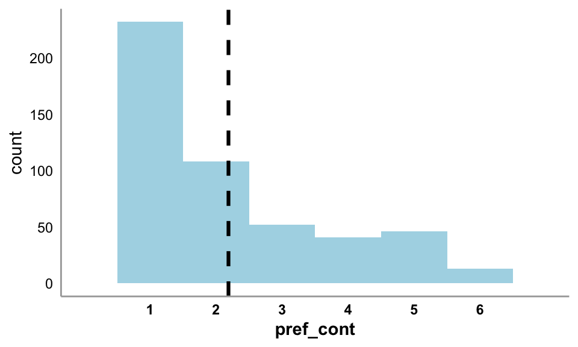

```r
df_s4_elg %>%
  ggplot(aes(x = pref_cont)) +
  geom_histogram(fill = "lightblue",
                 color = NA,
                 binwidth = 1) +
  scale_x_continuous(breaks = seq(1,6,1),
                     limits = c(0,7)) +
  ylab("count") +
  geom_vline(xintercept = mean(df_s4_elg$pref_cont,na.rm = T),
             color = "black",
             linetype = "dashed",
             size = 1.1) +
  theme(panel.grid.major = element_blank(),
        panel.grid.minor = element_blank(),
        panel.background = element_blank(),
        axis.ticks = element_blank(),
        axis.line = element_line(color = "grey66"),
        axis.text.y = element_text(color = "black"),
        axis.text.x = element_text(color = "black",
                                   face = "bold"),
        axis.title.x = element_text(color = "black",
                                   face = "bold"))
```

## Dominant message: Relationship expectancy

What will be the impact of this message on your employee’s attitude towards you? (1 = *Extremely Negative* to 7 = *Extremely Positive*)

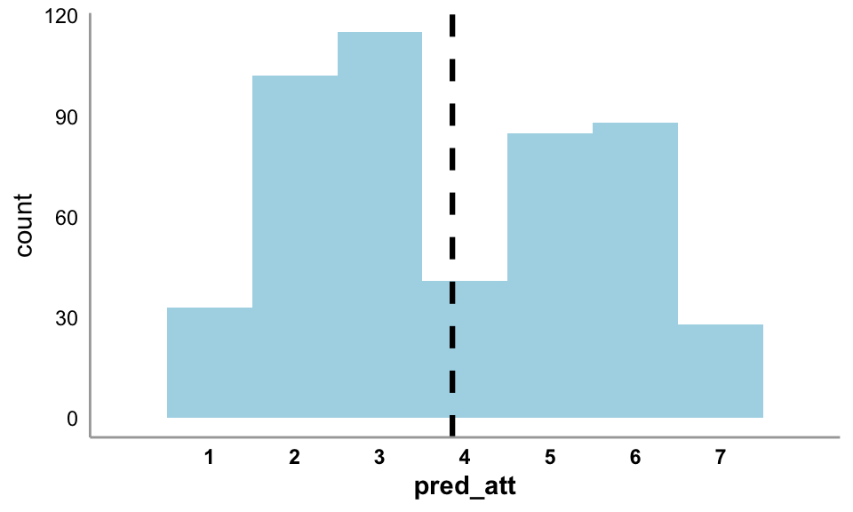

```r
df_s4_elg %>%
  ggplot(aes(x = pred_att)) +
  geom_histogram(fill = "lightblue",
                 color = NA,
                 binwidth = 1) +
  scale_x_continuous(breaks = seq(1,7,1),
                     limits = c(0,8)) +
  ylab("count") +
  geom_vline(xintercept = mean(df_s4_elg$pred_att,na.rm = T),
             color = "black",
             linetype = "dashed",
             size = 1.1) +
  theme(panel.grid.major = element_blank(),
        panel.grid.minor = element_blank(),
        panel.background = element_blank(),
        axis.ticks = element_blank(),
        axis.line = element_line(color = "grey66"),
        axis.text.y = element_text(color = "black"),
        axis.text.x = element_text(color = "black",
                                   face = "bold"),
        axis.title.x = element_text(color = "black",
                                   face = "bold"))
```

## Dominant message: Compliance expectancy

If they choose to do the task after receiving your message, how well will they perform? Their performance can range from 0 points up to 50 points (for perfect performance).

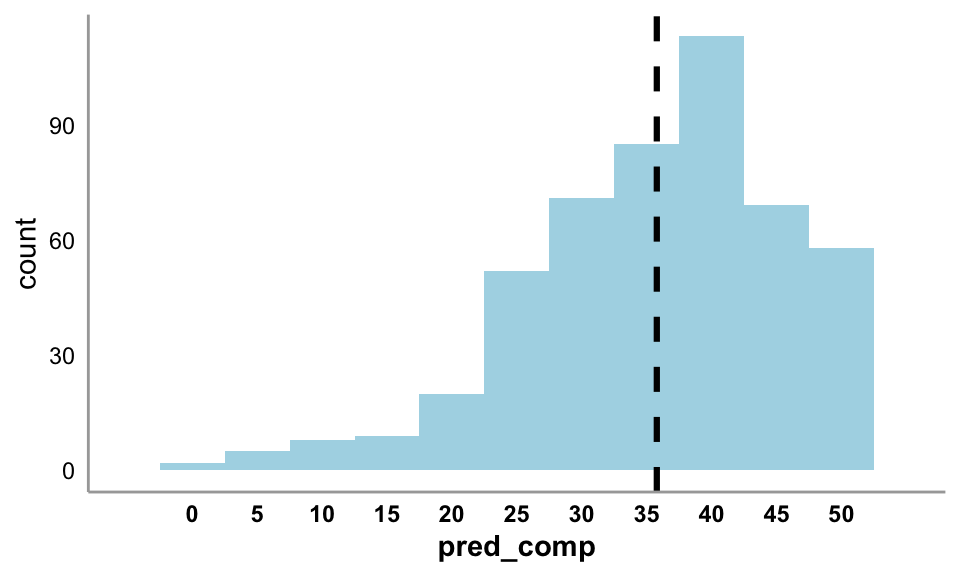

```r
df_s4_elg %>%
  ggplot(aes(x = pred_comp)) +
  geom_histogram(fill = "lightblue",
                 color = NA,
                 binwidth = 5) +
  scale_x_continuous(breaks = seq(0,50,5),
                     limits = c(-5,55)) +
  ylab("count") +
  geom_vline(xintercept = mean(df_s4_elg$pred_comp,na.rm = T),
             color = "black",
             linetype = "dashed",
             size = 1.1) +
  theme(panel.grid.major = element_blank(),
        panel.grid.minor = element_blank(),
        panel.background = element_blank(),
        axis.ticks = element_blank(),
        axis.line = element_line(color = "grey66"),
        axis.text.y = element_text(color = "black"),
        axis.text.x = element_text(color = "black",
                                   face = "bold"),
        axis.title.x = element_text(color = "black",
                                   face = "bold"))
```

## Competitive worldview

Finally, they completed the Competitive Worldview scale.

1 = *Strongly Disagree* to 7 = *Strongly Agree*

1. It’s a dog-eat-dog world where you have to be ruthless at times
2. Life is not governed by the “survival of the fittest.” We should let compassion and moral laws be our guide [R]
3. There is really no such thing as “right” and “wrong.” It all boils down to what you can get away with
4. One of the most useful skills a person should develop is how to look someone straight in the eye and lie convincingly
5. It is better to be loved than to be feared [R]
6. My knowledge and experience tell me that the social world we live in is basically a competitive “jungle” in which the fittest survive and succeed, in which power, wealth, and winning are everything, and might is right
7. Do unto others as you would have them do unto you, and never do anything unfair to someone else [R]
8. Basically people are objects to be quietly and coolly manipulated for one’s own benefit
9. Honesty is the best policy in all cases [R]
10. One should give others the benefit of the doubt. Most people are trustworthy if you have faith in them [R]

R indicates a reverse-scored item.

Cronbach’s alpha = 0.79

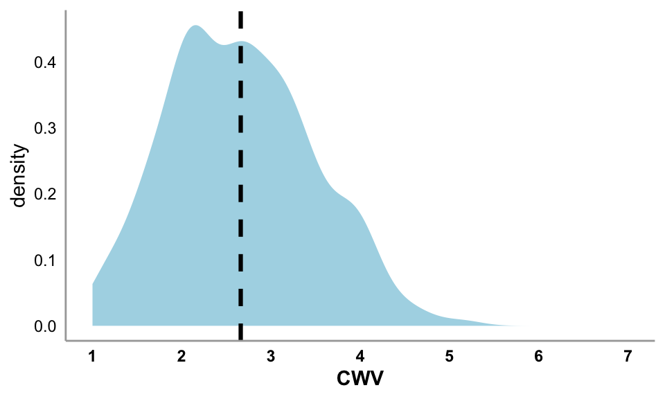

```r
df_s4_elg %>%
  ggplot(aes(x = CWV)) +
  geom_density(fill = "lightblue",
                 color = NA) +
  scale_x_continuous(breaks = seq(1,7,1),
                     limits = c(1,7)) +
  ylab("density") +
  geom_vline(xintercept = mean(df_s4_elg$CWV,na.rm = T),
             color = "black",
             linetype = "dashed",
             size = 1.1) +
  theme(panel.grid.major = element_blank(),
        panel.grid.minor = element_blank(),
        panel.background = element_blank(),
        axis.ticks = element_blank(),
        axis.line = element_line(color = "grey66"),
        axis.text.y = element_text(color = "black"),
        axis.text.x = element_text(color = "black",
                                   face = "bold"),
        axis.title.x = element_text(color = "black",
                                   face = "bold"))
```

# Analysis

## t-test 1

```r
df_s4_elg <- df_s4_elg %>%
  mutate(cond = factor(cond,levels = c("pos","neg")))

df_s4_elg %>%
  group_by(cond) %>%
  summarise(N = n(),
            Mean = mean(pred_att,na.rm = T),
            SD = sd(pred_att,na.rm = T)) %>%
  ungroup() %>%
  kbl() %>%
  kable_styling(bootstrap_options = "hover",
                full_width = F,
                position = "left")
```

| cond | N | Mean | SD |
| --- | --- | --- | --- |
| pos | 247 | 4.392713 | 1.648980 |
| neg | 245 | 3.306122 | 1.674349 |

```r
m <- t.test(pred_att ~ cond,data = df_s4_elg)
d_mod <- cohens_d(m)
d = d_mod[1,1]
```

*t*(489.73) = 7.25, *p* = 0, *Lower CI* = 0.79, *Upper CI* = 1.38, *d* = 0.66.

## t-test 2

```r
df_s4_elg %>%
  group_by(cond) %>%
  summarise(N = n(),
            Mean = mean(choicedom,na.rm = T),
            SD = sd(choicedom,na.rm = T)) %>%
  ungroup() %>%
  kbl() %>%
  kable_styling(bootstrap_options = "hover",
                full_width = F,
                position = "left")
```

| cond | N | Mean | SD |
| --- | --- | --- | --- |
| pos | 247 | 0.2955466 | 0.4572145 |
| neg | 245 | 0.1102041 | 0.3137850 |

```r
m <- t.test(choicedom ~ cond,data = df_s4_elg)
d_mod <- cohens_d(m)
d = d_mod[1,1]
```

*t*(435.98) = 5.25, *p* = 0, *Lower CI* = 0.12, *Upper CI* = 0.25, *d* = 0.5.

## t-test 3

```r
df_s4_elg %>%
  group_by(cond) %>%
  summarise(N = n(),
            Mean = mean(pref_cont,na.rm = T),
            SD = sd(pref_cont,na.rm = T)) %>%
  ungroup() %>%
  kbl() %>%
  kable_styling(bootstrap_options = "hover",
                full_width = F,
                position = "left")
```

| cond | N | Mean | SD |
| --- | --- | --- | --- |
| pos | 247 | 2.538461 | 1.629735 |
| neg | 245 | 1.832653 | 1.177206 |

```r
m <- t.test(pref_cont ~ cond,data = df_s4_elg)
d_mod <- cohens_d(m)
d = d_mod[1,1]
```

*t*(447.92) = 5.51, *p* = 0, *Lower CI* = 0.45, *Upper CI* = 0.96, *d* = 0.52.

## Mediation Model 1

Predictor: Condition (1 = positive; 0 = negative).

Mediator: Predicted relationship impact.

Outcome: Message selection (1 = dominant message; 0 = non-dominant message).

```r
# Step 1: Fit the mediator model
med.fit <- lm(pred_att ~ cond_num,
              data = df_s4_elg)

# Step 2: Fit the outcome model
out.fit <- lm(choicedom ~ cond_num + pred_att,
              data = df_s4_elg)

# Step 3: Conduct the mediation analysis
med.out <- mediation::mediate(med.fit, out.fit,
                   treat = "cond_num",
                   mediator = "pred_att",
                   boot = TRUE, sims = 10000)

# Step 4: Create table
med_results <- data.frame(
  Effect = c("ACME (indirect)", "ADE (direct)", "Total Effect", "Prop. Mediated"),
  Estimate = round(c(med.out$d0, med.out$z0, med.out$tau.coef, med.out$n0), 3),
  `95% CI Lower` = round(c(med.out$d0.ci[1], med.out$z0.ci[1], med.out$tau.ci[1], med.out$n0.ci[1]), 3),
  `95% CI Upper` = round(c(med.out$d0.ci[2], med.out$z0.ci[2], med.out$tau.ci[2], med.out$n0.ci[2]), 3),
  `p-value` = signif(c(med.out$d0.p, med.out$z0.p, med.out$tau.p, med.out$n0.p), 3)
)

kbl(med_results) %>%
  kable_styling(bootstrap_options = "hover",
                full_width = F,
                position = "left")
```

| Effect | Estimate | X95..CI.Lower | X95..CI.Upper | p.value |
| --- | --- | --- | --- | --- |
| ACME (indirect) | 0.058 | 0.036 | 0.085 | 0e+00 |
| ADE (direct) | 0.127 | 0.060 | 0.193 | 4e-04 |
| Total Effect | 0.185 | 0.115 | 0.255 | 0e+00 |
| Prop. Mediated | 0.312 | 0.191 | 0.530 | 0e+00 |

## Mediation Model 2

```r
model <- '
  # mediator models
  pred_att ~ a1*cond_num
  pred_comp ~ a2*cond_num

  # outcome model
  choicedom ~ c*cond_num + b1*pred_att + b2*pred_comp

  # indirect effects
  ind_att := a1 * b1
  ind_comp := a2 * b2
  total := c + ind_att + ind_comp
'

fit <- sem(model, data = df_s4_elg, se = "bootstrap", bootstrap = 10000)
estimates <- parameterEstimates(fit, standardized = TRUE, ci = TRUE)
table_results <- subset(estimates, label %in% c("a1", "b1", "a2", "b2", "c", "ind_att", "ind_comp", "total"))

# Rename paths for clarity
table_results$label <- recode(table_results$label,
                              "a1" = "a1: cond → pred_att",
                              "b1" = "b1: pred_att → choicedom",
                              "a2" = "a2: cond → pred_comp",
                              "b2" = "b2: pred_comp → choicedom",
                              "c"  = "Direct effect (c')",
                              "ind_att" = "Indirect via pred_att",
                              "ind_comp" = "Indirect via pred_comp",
                              "total" = "Total effect")

# Select and rename columns
output_table <- table_results[, c("label", "est", "ci.lower", "ci.upper", "pvalue")]
names(output_table) <- c("Path", "Estimate", "95% CI Lower", "95% CI Upper", "p-value")

# Round for reporting
output_table[2:5] <- lapply(output_table[2:5], function(x) signif(x, 3))

# Print table
kbl(output_table) %>%
  kable_styling(bootstrap_options = "hover",
                full_width = F,
                position = "left")
```

|  | Path | Estimate | 95% CI Lower | 95% CI Upper | p-value |
| --- | --- | --- | --- | --- | --- |
| 1 | a1: cond → pred_att | 1.09000 | 0.794000 | 1.38000 | 0.00e+00 |
| 2 | a2: cond → pred_comp | 2.58000 | 0.796000 | 4.32000 | 4.21e-03 |
| 3 | Direct effect (c’) | 0.12900 | 0.061300 | 0.19700 | 1.88e-04 |
| 4 | b1: pred_att → choicedom | 0.04310 | 0.024200 | 0.06370 | 1.76e-05 |
| 5 | b2: pred_comp → choicedom | 0.00378 | 0.000709 | 0.00685 | 1.55e-02 |
| 10 | Indirect via pred_att | 0.04680 | 0.024200 | 0.07450 | 3.03e-04 |
| 11 | Indirect via pred_comp | 0.00976 | 0.001200 | 0.02130 | 6.08e-02 |
| 12 | Total effect | 0.18500 | 0.116000 | 0.25600 | 2.00e-07 |

## Linear Model 1

Predictor: Condition (1 = positive; 0 = negative).

Moderator: Competitive worldview.

Outcome: Message selection (1 = dominant message; 0 = non-dominant message).

```r
m1 <- lm(choicedom ~ cond_num*CWV,data = df_s4_elg)

eta_table <- eta_squared(m1)
etas_for_table <- c(NA,eta_table$Eta2_partial)
apa_lm <- apa_print(m1)
table_for_print <- apa_lm$table %>%
  mutate(eta2 = round(etas_for_table,3))

kbl(table_for_print) %>%
  kable_styling(bootstrap_options = "hover",
                full_width = F,
                position = "left")
```

| term | estimate | conf.int | statistic | df | p.value | eta2 |
| --- | --- | --- | --- | --- | --- | --- |
| Intercept | -0.07 | [-0.23, 0.10] | -0.78 | 488 | .438 | NA |
| Cond num | 0.39 | [0.15, 0.63] | 3.23 | 488 | .001 | 0.054 |
| CWV | 0.07 | [0.01, 0.13] | 2.17 | 488 | .031 | 0.003 |
| Cond num $\times$ CWV | -0.08 | [-0.16, 0.01] | -1.78 | 488 | .076 | 0.006 |